# R Tutorial at the WZB

October 25, 2018

## About me

- Markus Konrad
  - markus.konrad@wzb.eu
  - tel -555
  - office D005
- studied Computer Science (MSc.) at HTW Berlin
- worked at HTW Berlin and at Excellence Cluster Topoi before
- working at WZB as Data Scientist in IT dept. since April 2016
- mainly working with Python and R

## Important notes and documents

- weekly course, except for three weeks in November (see tutorial schedule)
- each Thursday 10am-12pm, B001 or B002/3
- usual structure: first input presentation, then some tasks to solve
- presentation slides, scripts, tasks, solutions and datasets at https://wzbsocialsciencecenter.github.io/wzb_r_tutorial/
- contact: markus.konrad@wzb.eu

**If you don't understand something, please ask!**

## Literature and other sources

- *Grolemund & Wickham 2017: R for Data Science* (avail. [online for free](http://r4ds.had.co.nz/))
- *Kabacoff 2015: R in Action*
- *Salganik 2017: Bit by Bit* (avail. [online for free](https://www.bitbybitbook.com/))
- *Chang 2013: R Graphics Cookbook*
- interactive [SWIRL tutorials](https://swirlstats.com/)
- [R programming course](https://www.coursera.org/learn/r-programming) by John Hopkins Univ. / Roger Peng at Coursera

## Tutorial schedule

- today: Getting to know *R* and *RStudio*
- next week: R Basics I
- Week 3: R Basics II **(self-study, no tutorial at WZB)**
- Week 4: R Basics III **(self-study, no tutorial at WZB)**
- Week 5: Transforming data with R I **(self-study, no tutorial at WZB)**
- Week 6: Recap / Transforming data with R II / plotting with ggplot2
- Week 7: Working with geo-spatial data / Record linkage
- Week 8: Working with large datasets (replicating Michel et al. 2011)
- Week 9: Guest speaker Taylor Brown → Quantitative text analysis with R I

– *Christmas and New Years Eve break* –

## What to expect

You'll learn *modern* R to do:

- "data wrangling" (transform data)
- record linkage (merging / joining datasets)
- explorative data analysis (EDA) with descriptive statistics and data visualizations
- quantitative text analysis
- "Big Data" API querying and integration

## What *not* to expect

**This is not a statistics course.**

→ we'll focus is on data preparation, EDA and visualization

For statistics with R see:

- *Dalgaard 2008: Introductory Statistics with R*
- *Field & Miles 2012: Discovering Statistics using R*
- *Matloff 2017: Statistical Regression and Classification*
- *Kuhn & Johnson 2013: Applied Predictive Modeling*

## What *not* to expect

**This is not an in-depth programming course.**

→ we'll write short scripts and learn some fundamental concepts of programming

For programming with R see:

- *Wickham 2014: Advanced R*
- *Grolemund 2014: Hands-On Programming with R: Write Your Own Functions and Simulations*
- *Matloff 2011: The Art of R Programming*

## What is R?

- a **free**, **open-source** **statistical programming language** and **computing environment**
- based on *S* language developed at Bell Labs
- initially developed in 1993 by **R**oss Ihaka and **R**obert Gentleman at University of Auckland, New Zealand
- currently 25th anniversary!

## Why R?

- free and open-source
- runs on all major Operating Systems
- well tested and trusted software base
- combines flexible programming model with wide range of statistical methods
- active development and broad community
- easily extensible through *R packages*

## Why R?

increasingly popular, esp. in the science community

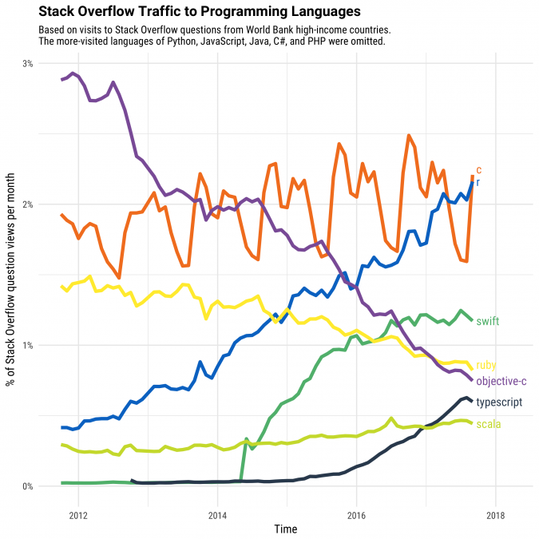

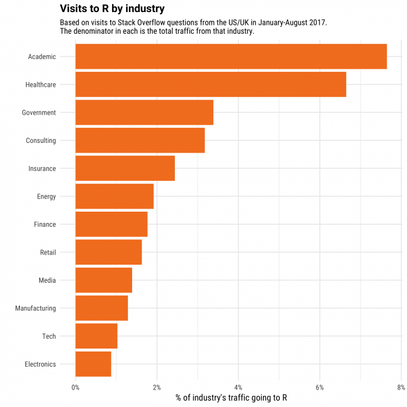

*source: [StackOverflow](https://stackoverflow.blog/2017/10/10/impressive-growth-r/)*

## "Base R" and the "tidyverse"

**"Base R" or "R Core": Core functions of the R language without additional packages**

- syntax of R "historically grown" since 25 years → many ambiguities, differing concepts
- can be awkward and confusing for beginners

```r
with(airquality, sapply(split(Ozone, Month), mean, na.rm = TRUE))
```

## "Base R" and the "tidyverse"

[figure not shown]

source: [tidyverse.org](https://www.tidyverse.org/)

**tidyverse: set of packages that share the same "design philosophy, grammar, and data structures"**

- https://www.tidyverse.org/
- tries to modernize R language; fosters better readable code

```r
airquality %>%
  group_by(Month) %>%
  summarize(m_oz = mean(Ozone, na.rm = TRUE))
```

## "Base R" and the "tidyverse"

Base R:

```r
with(airquality, sapply(split(Ozone, Month), mean, na.rm = TRUE))
```

tidyverse:

```r
airquality %>%
  group_by(Month) %>%
  summarize(m_oz = mean(Ozone, na.rm = TRUE))
```

## R packages and CRAN

R's functionality can be extended by *packages* which are available in the *Comprehensive R Archive Network (CRAN)*.

Popular packages include:

- *ggplot2* (data visualization)
- *dplyr* and *tidyr* (data manipulation)
- *foreign* (read/write data from Stata, SPSS, SAS, etc.)
- *RColorBrewer* (popular color schemes from [colorbrewer](http://colorbrewer2.org))
- *caret* and *Keras* (advanced regression and machine learning models)

## Let's get started

## RStudio

- *RStudio* is an **Integrated development environment (IDE)** for R
- it's a comfortable **interface** to R
- analogy: if R is the engine, then RStudio is the car around it
- offers:
  - interactive console
  - script editor with error checking
  - package manager
  - data, plot and file viewers
  - …

## RStudio Server

**Only for WZB staff:**

For those who can't / don't want to install RStudio on their computer there's an option to use RStudio via the browser:

https://rstudio.wzb.eu

Use your WZB login there.

## Working interactively: Using the Console

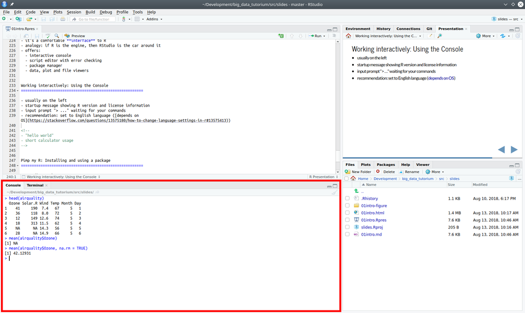

## Working interactively: Console tips & tricks

- usually on the (lower) left
- startup message showing R version and license information
- input **prompt** "> …" waiting for your commands (commands are issued using ENTER)
- output: depends on data type
- **general hint: all commands are case sensitive**
- recommendation: set to English language ([depends on OS](https://stackoverflow.com/questions/13575180/how-to-change-language-settings-in-r#13575413))

## Some general R syntax rules

- a *syntax* describes the general rules of a programming language
- it's like a grammar in a natural language, however, a programming language is **very** strict about the grammar

Some general rules:

**1. Each line is a statement ("command"), several statements are evaluated from top to bottom.**

```r
c <- a + b
d <- sqrt(c)
```

**Exception:** If an expression is not closed (see paranthesis rule below), it can span several lines:

```r
a * (b
+ c
+ d)
```

This is the same as `a * (b + c + d)`.

## Some general R syntax rules

**2. Spaces are generally ignored.**

These are all equivalent:

```r
a+b
a + b
a    +  b
```

Use spaces and indents to make your code more readable.

## Some general R syntax rules

**3. Expressions must be closed.**

There are different special characters, that mark the beginning and end of something, e.g. the beginning and end of a character string or an expression:

```r
"hello world"
a * (b + c)
x[1]
```

More complex statements contain nested expressions. Nested expressions are evaluated from inner to outer.

```r
y[c(1, 3)]
```

**For each opened paranthesis, quotation mark, etc. there must be a closing counterpart in the correct order.** This would be wrong:

```r
y[c(1, 3])
## Error: unexpected ']'
```

## Some general R syntax rules

**4. Comma and dots**

Comma split things: Mainly *arguments (parameters)* of *functions*.

```r
log(x, 5)
```

→ passes the parameters `x` and `5` to compute the base 5 logarithm of `x`.

Comma **cannot** be used to group digits in large numbers:

```r
population <- 3,350,000
## Error: unexpected ',' in "population <- 3,"
```

A dot is used as decimal point:

```r
3.1415
```

## Pimp my R: Installing and using a package

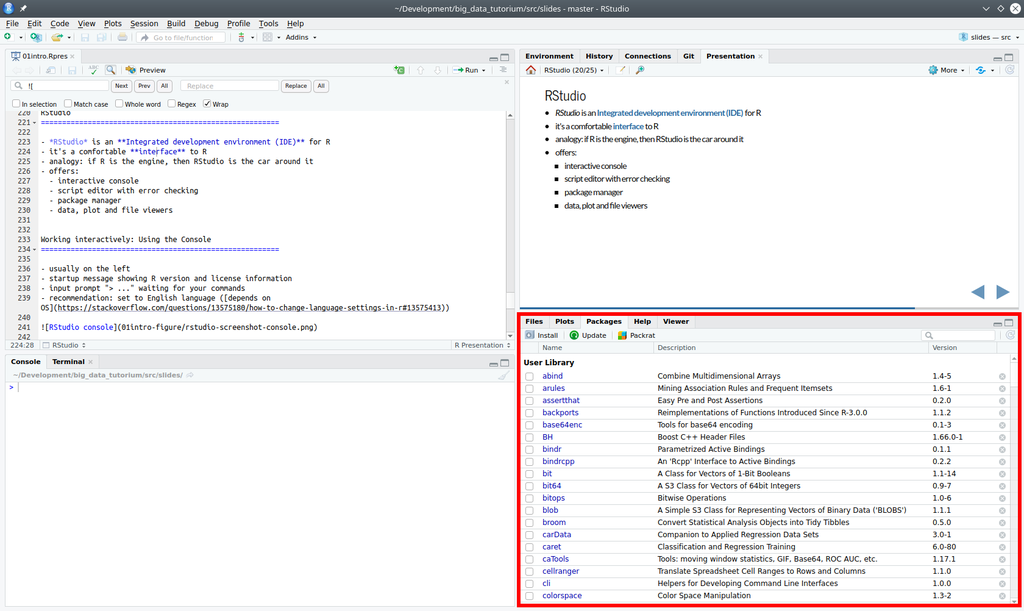

## Pimp my R: Package manager in RStudio

- packages (aka "libraries") extend R's functionality
- on the right, "Packages" tab
- allows to view, install and update R packages from CRAN
- **first task for you:** install the following packages
  - *tidyverse* (this is a *meta-package* containing lots of other packages – it will take a while)
  - *swirl* (this is package for interactive exercises that we'll use later)

## Pimp my R: Package manager tips & tricks

- alternative: use command on Console:

  `install.packages("<PACKAGE_NAME>")`
- then, to load a package:

  `library(<PACKAGE_NAME>)` (without quotation marks!)

```r
install.packages("tidyverse")
library(tidyverse)
```

## Pimp my R: Package manager tips & tricks

If you forget to load a package, you will be confronted with errors like these:

```r
qplot()
## Error in qplot() : could not find function "qplot"
diamonds
## Error: object 'diamonds' not found
```

## Knowing where you R: The working directory concept

- the *working directory* or *path* is the location on your computer's drive, at which your current R session is working
- reading files, writing files, etc. is **relative to this path**
- finding out the current working path: `getwd()`
- setting the working path: `setwd("<PATH>")`
- **absolute path:** path starts with `/` (MacOS / Unix) or `C:\`
  - depends on your *personal* folder structure
- **relative path:** path starts directly with a file or folder name
  - relative from some other path, e.g. the current working path

## Knowing where you R: An example

- `getwd()` returns `"/Users/NoName/Documents"`
- the file you want to load is at `/Users/NoName/Documents/MyProject/data.csv`
- you can load the file with: `read.csv("MyProject/data.csv")`
- what if the working path were at…
  - `/Users/NoName/Documents/MyProject`?
  - `/Users/NoName/Research`?

## Tips for file and folder names

- do not use spaces (use `_` instead)
  - "funny file name .xlsx" – how many spaces do you count?
- try to stick to the English alphabet, avoid special characters
- keep it short
- can be case sensitive
- for a single project, use the same root directory for scripts and data
- do not use absolute paths in your code → it will only run on your computer!

## RStudio file manager

[figure not shown]

- on the right, "Files" tab
- "More" button allows to "Set as Working Directory" and "Go to Working Directory"

## Calling the Rescue team: Getting help

Using R's internal help system:

- `help(<SYMBOL>)` / shortcut: `?<SYMBOL>`
- `<SYMBOL>` can be anything: a function, a package, a data set
- shown on the right lower side in the "Help" tab in RStudio
- example: `?getwd` or `?mean`

## Calling the Rescue team: Getting help

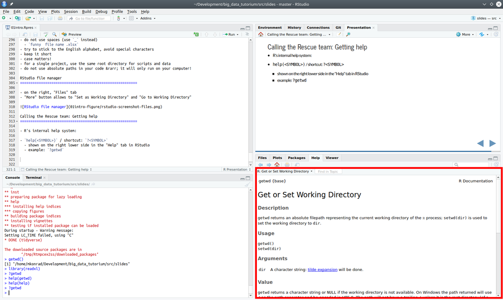

## Other useful help functions

- show example usages: `example(<SYMBOL>)`

```r
example(mean)
## mean> x <- c(0:10, 50)
## mean> xm <- mean(x)
## mean> c(xm, mean(x, trim = 0.10))
## [1] 8.75 5.50
```

- list all available functions containing a keyword: `apropos("<SEARCH>")`

```r
apropos('matrix')
## [1] "anyDuplicated.matrix"       "as.data.frame.matrix" ...
## [4] "as.matrix"                  "as.matrix.data.frame" ...
```

## Other useful help functions: Vignettes and online help

*Vignettes* provide a short introduction to a specific package, function or topic. Not all packages offer a vignette.

- `vignette()` shows all available vignettes
- `vignette('<TOPIC>')` openes a vignette for a specific topic (e.g. `vignette('dplyr')` → introduction to the *dplyr* package in the help viewer)
- packages have info page on CRAN (search online for "cran ")
  - example: [ggplot2 CRAN page](https://cran.r-project.org/web/packages/ggplot2/index.html)
- many packages have own websites / online documentation, especially the tidyverse packages ([tidyverse.org](https://www.tidyverse.org/))

## Handling problems and frustration

- R has a steep learning curve
- but it's worth the effort!
- programming languages are not *fault tolerant*, they're relentless in case of typos, syntax errors, etc.
- you need to be exact
- if you know R, you can learn other programming languages easier
- BUT: better don't try to learn more than one programming language at once

## In case of fire, do not run

If you encounter an error:

- look closely and/or let someone else look closely
- break into smaller pieces and repeat
- use minimal data to reproduce error
- have a look at examples that use the similar functions or make similar calculations
- learn to use a *debugger* *
- search for help online (see tips on next slide)
  - [StackOverflow](https://stackoverflow.com/)
  - [R-help mailinglist](https://www.r-project.org/mail.html)

* Maybe we'll have a session on this later in the semester.

## Getting help online

Web search query patterns:

- `"r <PACKAGE> <PROBLEM>"`
- `"r <PROBLEM>"`

Reduce error messages to the general problem:

```r
summarize(airquality, m_oz = mean(SolarR))
## Error in summarise_impl(.data, dots): Evaluation error:
## object 'SolarR' not found.
```

→ possible search query: `"r dplyr summarize object not found"`

## Getting help online

Example 2:

```r
mean(airquality$Ozone)
## [1] NA
```

→ possible search query: `"r mean always returns NA"`

Example 3:

Sometimes, error messages provide hints:

```r
filter(airquality, Month = 7)
## Error: `Month` (`Month = 7`) must not be named, do you need `==`?
```

## Tasks

## Tasks

[figure not shown]

source: [attackofthecute.com](http://attackofthecute.com/)

1. If not done already, install the packages, *tidyverse*, *swirl* and *MASS*
2. Load the packages *MASS* and *tidyverse*. Loading these packages will produce some messages on the console. What do you think do they mean? (If you don't know, just make a wild guess!)
3. Load the builtin dataset "cats" provided by the package MASS (Hint: Run `data(cats)` to load the data)
4. Inform yourself about the data using R's help system – What are the variables in the dataset?
5. View the data using 4 different perspectives:
   - Issue simply the command `cats` at the console – What generally happens when you simply use an object's name as command?
   - Using the functions `head` and `tail`.
   - Using RStudios `View` function (use the function from the console and also check out the small table icon in the "Environment" tab in the top right pane)
6. Construct a *scatter plot* of the data using `qplot` from the *ggplot2* package (incl. in *tidyverse*)
   - inform yourself on the Web, about what a scatter plot is
   - see the documentation for `qplot` in R's help system
   - plot `Bwt` (body weight) on the x-axis and `Hwt` (heart weight) on the y-axis
   - Hint: a scatterplot can be generated with a command like this:
   - `qplot(<VARIABLE ON X>, <VARIABLE ON Y>, data = <DATASET>)`